# **Customizing ggplot**

[STOR 390](https://idc9.github.io/stor390/)

The primary references for this lecture are

- [r4ds chapter 28](http://r4ds.had.co.nz/graphics-for-communication.html#scales)
- [ggplot theme vignette](http://docs.ggplot2.org/dev/vignettes/themes.html)
- [ggplot theme documentation](http://docs.ggplot2.org/0.9.2.1/theme.html)

These notes contain some basic examples and the references are a more comprehensive overview.

# **Load data**

```r
library(tidyverse)
data<- read_csv('https://raw.githubusercontent.com/idc9/stor390/master/data/movies.csv')
```

# **Basic plot**

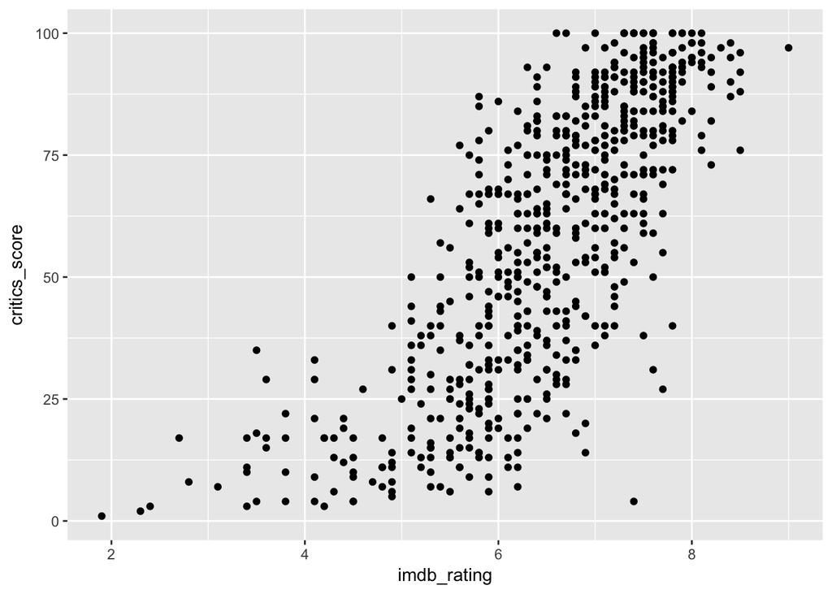

```r
ggplot(data=data) +
    geom_point(aes(x=imdb_rating, y=critics_score))
```

# **Labels**

## axis, title

`ggplot` will label the axes with the original variable names – let’s change that (and add a title). See [r4ds 28.2](http://r4ds.had.co.nz/graphics-for-communication.html#label) for more information.

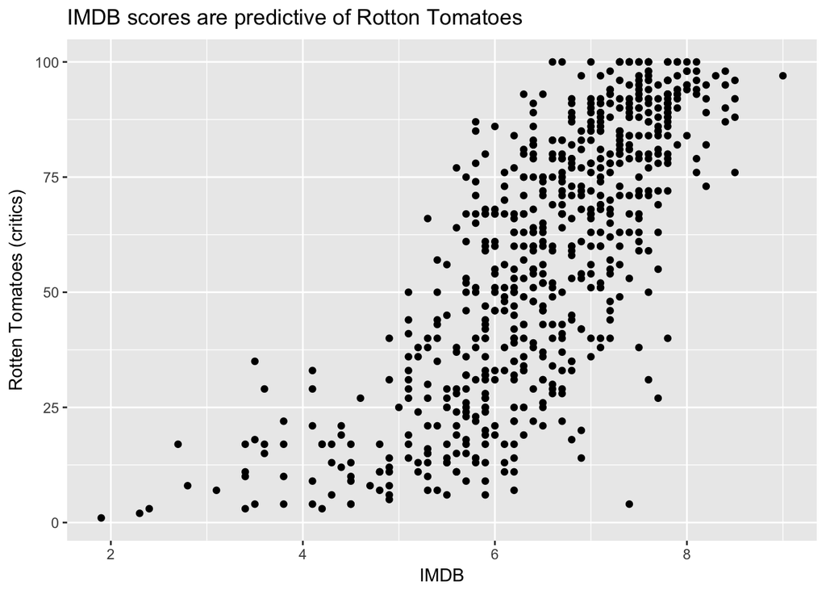

```r
# add labs()
ggplot(data=data) +
    geom_point(aes(x=imdb_rating, y=critics_score)) +
    labs(x='IMDB',
         y='Rotten Tomatoes (critics)',
         title='IMDB scores are predictive of Rotton Tomatoes')
```

```r
# using ggtitle, xlab
# ggplot(data=data) +
#     geom_point(aes(x=imdb_rating, y=critics_score)) +
#     ggtitle('IMDB scores are predictive of Rotton Tomatoes') +
#     xlab('IMDB')
```

If you do a variable transformation in the `geom_` ggplot will automatically add the transformation.

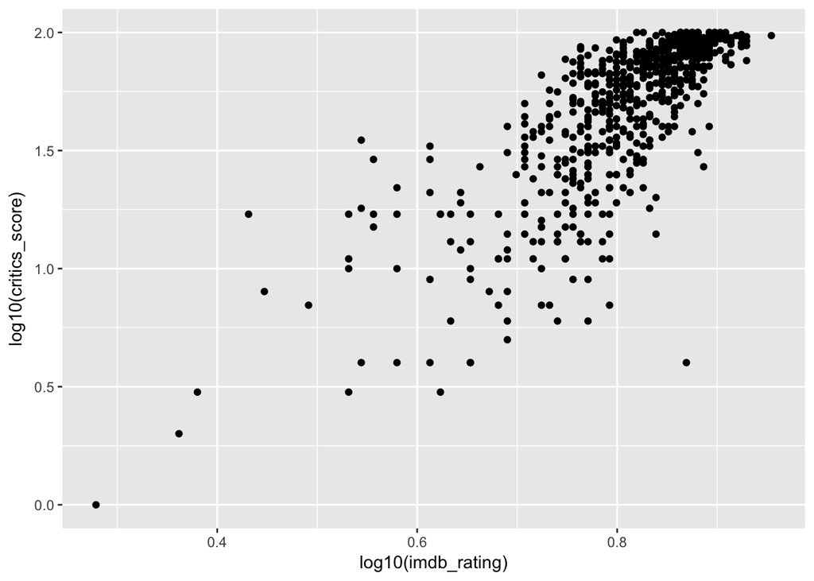

```r
# add labs()
ggplot(data=data) +
    geom_point(aes(x=log10(imdb_rating), y=log10(critics_score)))
```

## Annotation

Sometimes it’s useful to annotate a point.

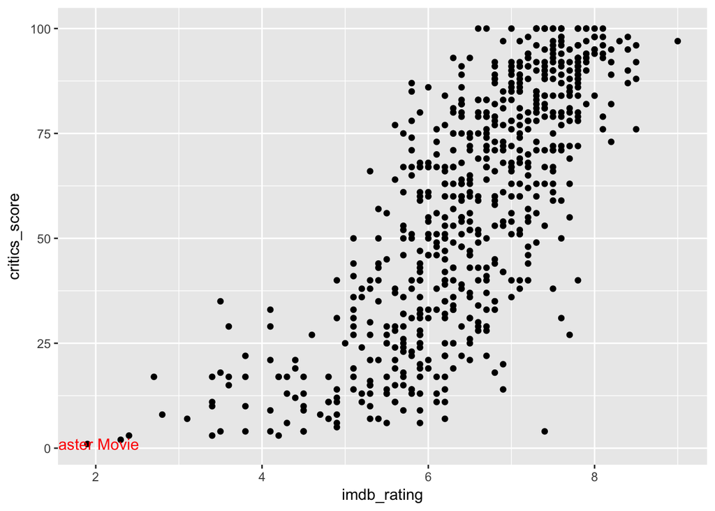

```r
# data frame for annotation
bad_movie <- data %>%
    filter(critics_score== min(critics_score))


# add text label
ggplot(data=data) +
    geom_point(aes(x=imdb_rating, y=critics_score)) +
    geom_text(data=bad_movie, aes(x=imdb_rating, y=critics_score, label=title), color='red')
```

The label goes off the plot – let’s nudge it back onto the plot.

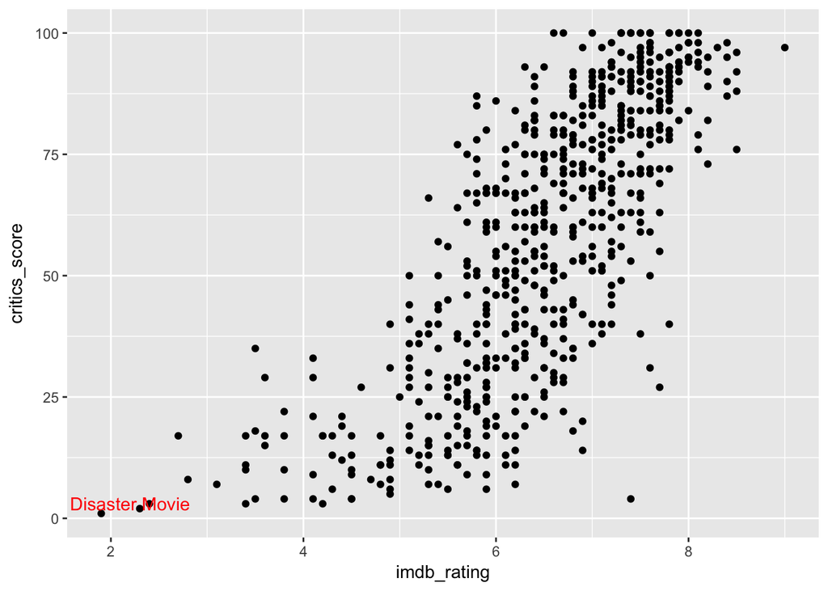

```r
ggplot(data=data) +
    geom_point(aes(x=imdb_rating, y=critics_score)) +
    geom_text(data=bad_movie, aes(x=imdb_rating, y=critics_score, label=title),color='red', nudge_x= .3, nudge_y= 2)
```

Like everything in `ggplot`, `geom_text` takes a data frame as input. You can also use this to add text anywhere to the plot.

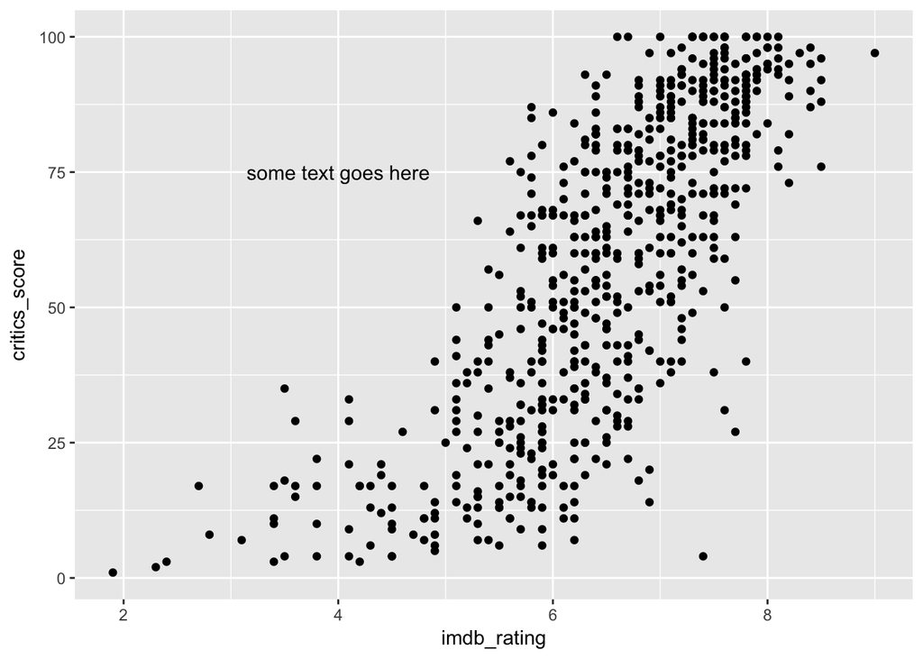

```r
# data frame storing some text and the position the text should go on the plot
text_df <- tibble(x=4, y=75, text='some text goes here')

ggplot(data=data) +
    geom_point(aes(x=imdb_rating, y=critics_score)) +
    geom_text(data=text_df, aes(x=x, y=y, label=text))
```

## axis limits

You can set the axis limits by adding `lims()`.

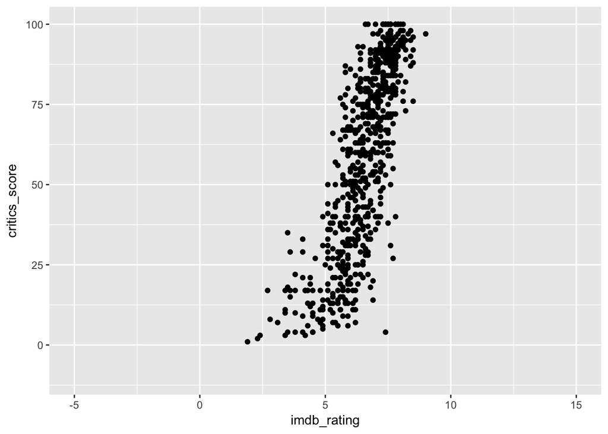

```r
ggplot(data=data) +
    geom_point(aes(x=imdb_rating, y=critics_score)) +
    lims(x=c(-5, 15), y=c(-10, 100))
```

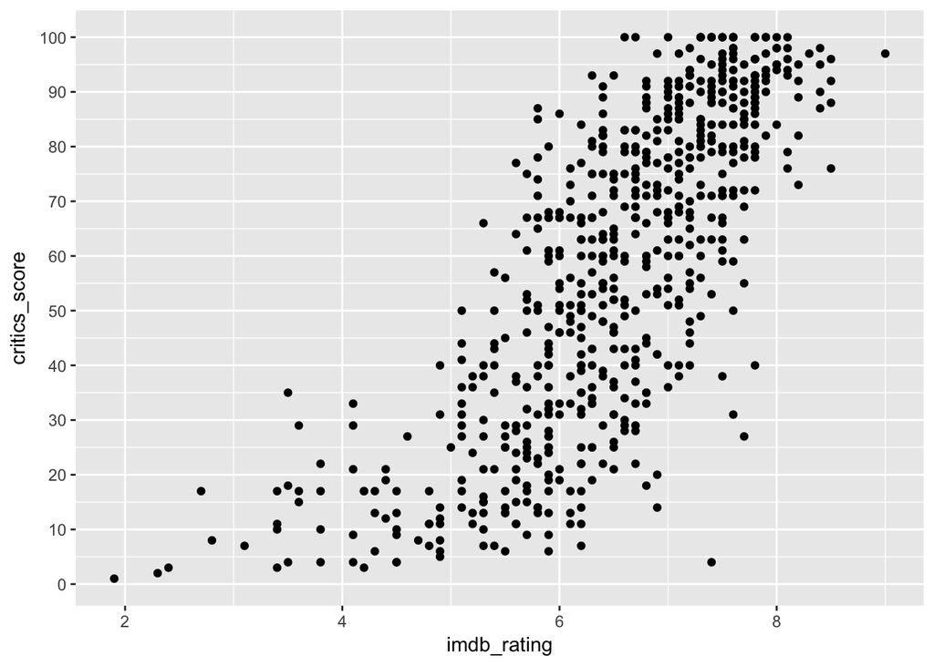

```r
ggplot(data=data) +
    geom_point(aes(x=imdb_rating, y=critics_score)) +
    scale_y_continuous(breaks=seq(from=0, to=100, by=10))
```

# **Theme**

The `theme` controls the plot background and the legend. See the [theme documentation](http://docs.ggplot2.org/0.9.2.1/theme.html) for a long list of examples of what you can do. Below are a few important examples.

## Change the background

By default `ggplot` uses a grey background – let’s make a blank background.

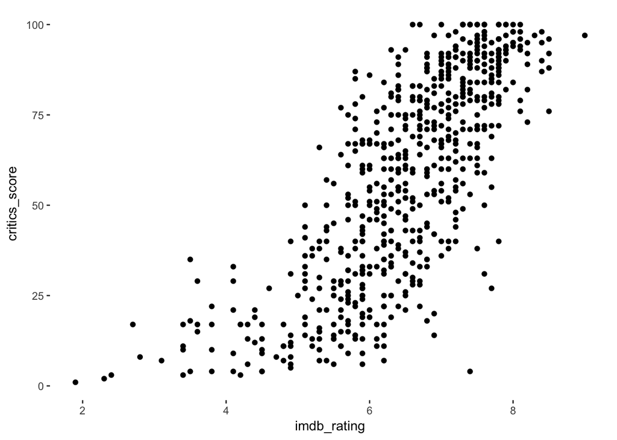

```r
ggplot(data=data) +
    geom_point(aes(x=imdb_rating, y=critics_score)) +
    theme(panel.background = element_blank())
```

# **Legend**

Adding additional aesthetic mappings like color or shape will automatically add a legend.

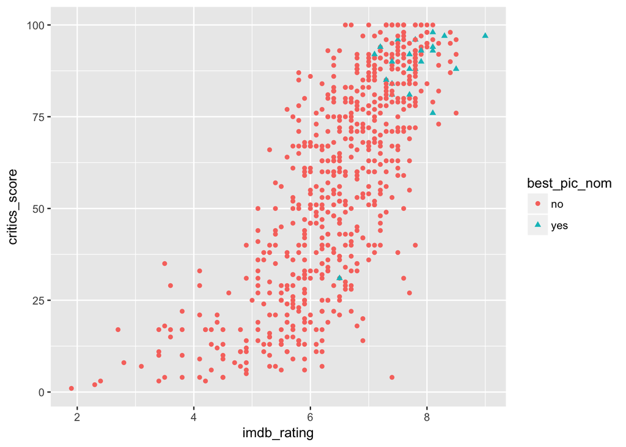

```r
ggplot(data=data) +
    geom_point(aes(x=imdb_rating, y=critics_score, color=best_pic_nom, shape=best_pic_nom))
```

Change the legend position

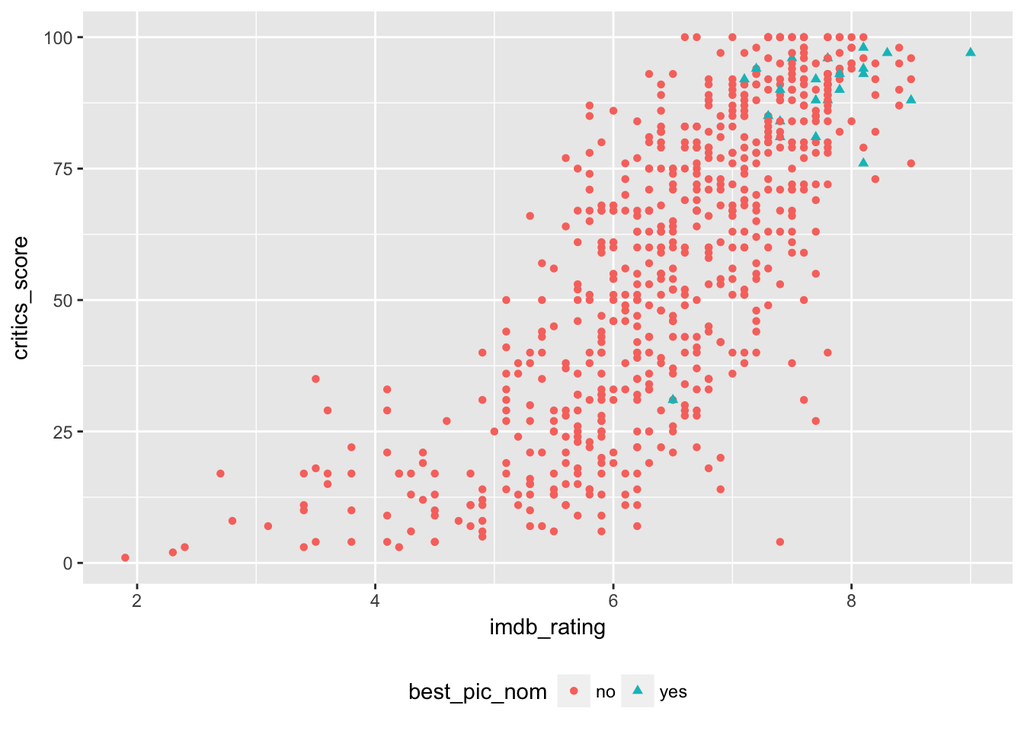

```r
ggplot(data=data) +
    geom_point(aes(x=imdb_rating, y=critics_score, color=best_pic_nom, shape=best_pic_nom)) +
    theme(legend.position = "bottom")
```

Or turn the legend off

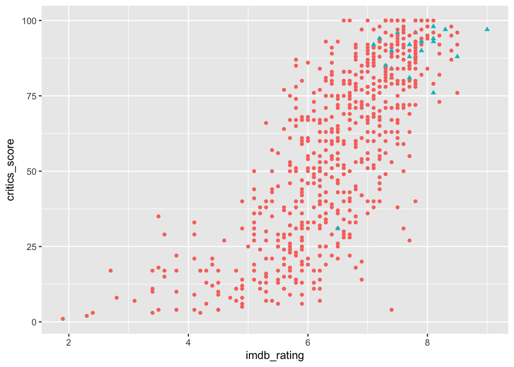

```r
ggplot(data=data) +
    geom_point(aes(x=imdb_rating, y=critics_score, color=best_pic_nom, shape=best_pic_nom)) +
    theme(legend.position = "none")
```

## Customize colors

`ggplot` has default colors/shapes. You can customize the color with `scale_colour_manual`.

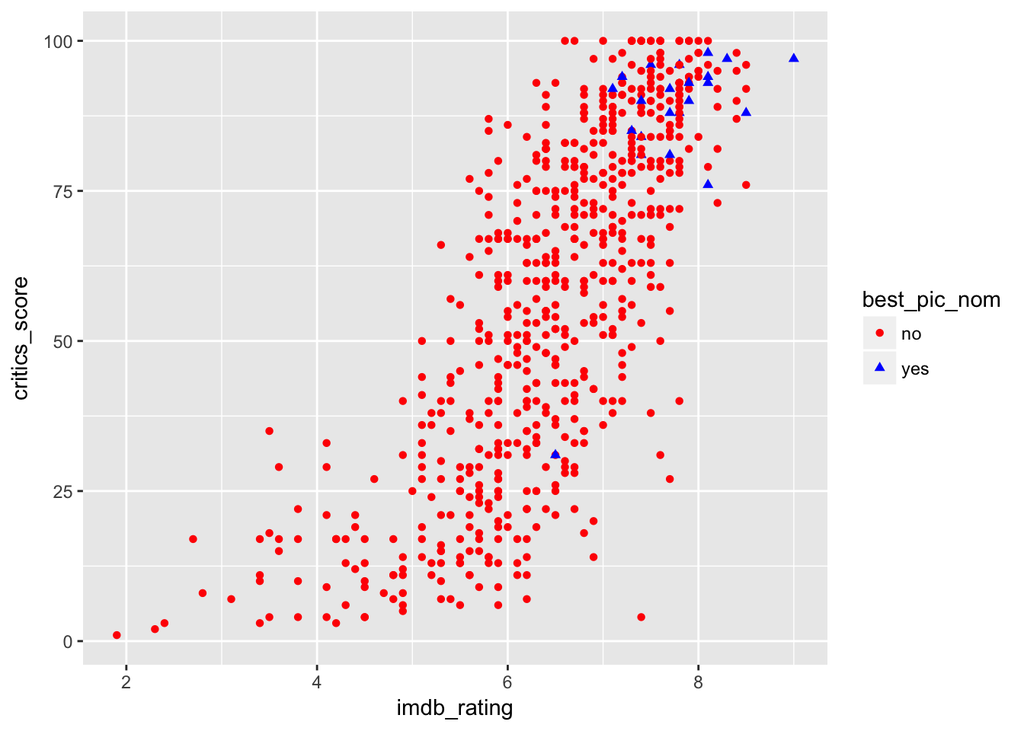

```r
ggplot(data=data) +
    geom_point(aes(x=imdb_rating, y=critics_score, color=best_pic_nom, shape=best_pic_nom)) +
    scale_colour_manual(values = c(no = "red", yes = "blue"))
```

Each of the aesthetic mapping (color, shape, fill, etc) have their own `scale_BLAH_manual`. For example, we could also change the size and shape

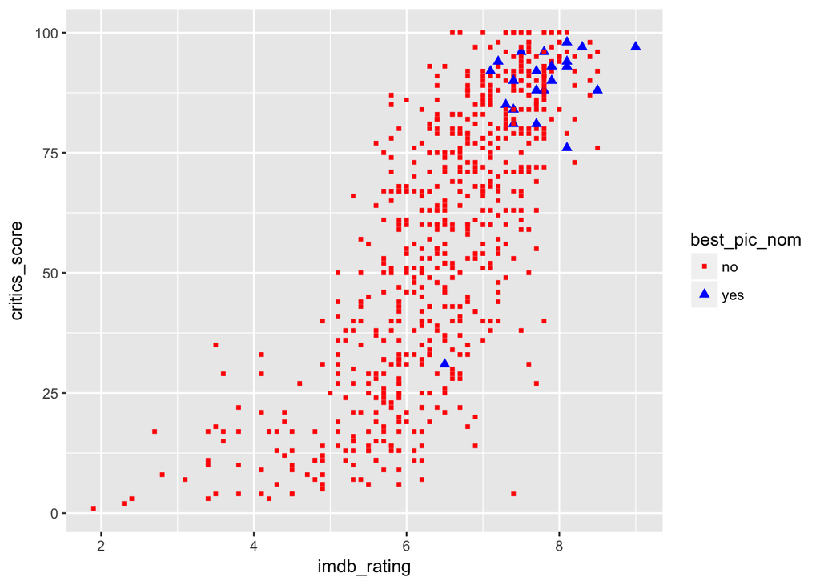

```r
ggplot(data=data) +
    geom_point(aes(x=imdb_rating, y=critics_score, color=best_pic_nom, shape=best_pic_nom, size=best_pic_nom)) +
    scale_colour_manual(values = c(no = "red", yes = "blue")) +
    scale_size_manual(values = c(no = 1, yes = 2)) +
    scale_shape_manual(values = c(no = 15, yes = 17))
```

[output not shown]